# 4b

Yiqiao Yin

2/7/2021

Hierarchical models and multiple comparisons

### Reproduce the probabilities in S 5.5.

First let us create data and then let us generate posterior $\tau$. Last, we plot the posterior $\tau$ on a graph.

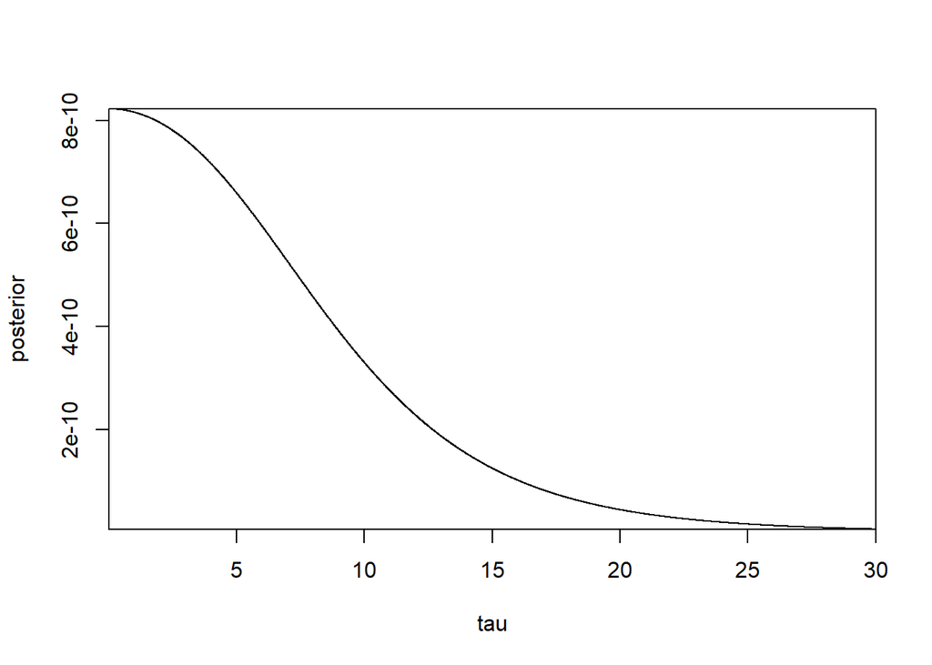

```r
y = c(28, 8, -3, 7, -1, 1, 18, 12)
sigma2 = c(15, 10, 16, 11, 9, 11, 10, 18)^2
J = length(y)


varInverse = function(sigma2, tau){
  sum(1/(sigma2+tau^2))
}

muHat = function(y, sigma2, tau){
  sum(1/(sigma2+tau^2) * y) / varInverse(sigma2, tau)
}

post_tau = function(y, sigma2, tau, mu_h){
  varInverse(sigma2, tau)^(-1/2)  * prod((sigma2 + tau^2)^(-1/2) * exp(-(y - mu_h)^2 / (2*(sigma2 + tau^2))))
}

interval = 0.01
max = 30

tau = (1:(max/interval)) * interval
post = tau

for (i in 1:length(tau)){
  mu_h = muHat(y, sigma2, tau[i])
  post[i] = post_tau(y, sigma2, tau[i], mu_h)
}

posterior = data.frame(tau, post)
plot(posterior, xaxs = "i", yaxs = "i",
     type = "l", ylab = "posterior", xlab = "tau")
```

Next, we simulate from $p(\tau|y)$ the posterior parameter $\tau$ given data $y$.

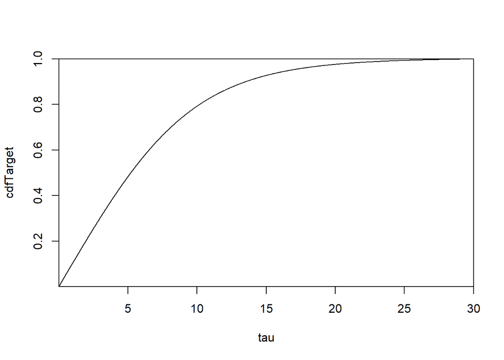

```r
normPosterior = post/sum(post*interval)
cdfTarget = cumsum(normPosterior) * interval
cdfDF = data.frame(tau, cdfTarget)
plot(cdfDF, xaxs = "i", yaxs = "i", type = "l")
```

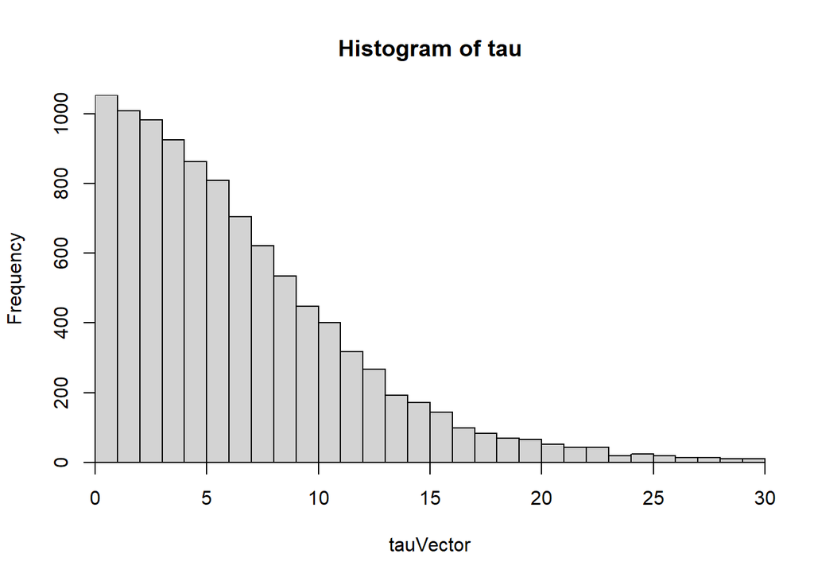

```r
N = 10000
uniDF = runif(N, 0, 1)
tauVector = rep(NA, N)
for (i in 1:N) {
  tauVector[i] = (sum(cdfTarget < uniDF[i])+1) * interval
}

hist(tauVector, breaks = 30, xaxs = "i", yaxs = "i",
     main = "Histogram of tau")
```

We simulate $\mu|\tau,y$.

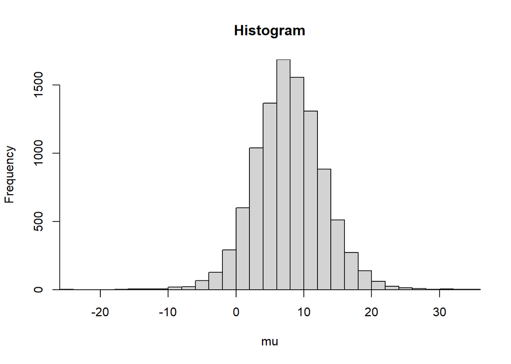

```r
muVec = rep(NA, N)
for (i in 1:N) {
  muVec[i] = rnorm(1, muHat(y, sigma2, tauVector[i]), varInverse(sigma2, tauVector[i])^(-.5))
}

hist(muVec, xaxs = "i", yaxs = "i",
     xlab = "mu",
     main = "Histogram", breaks = 30)
```

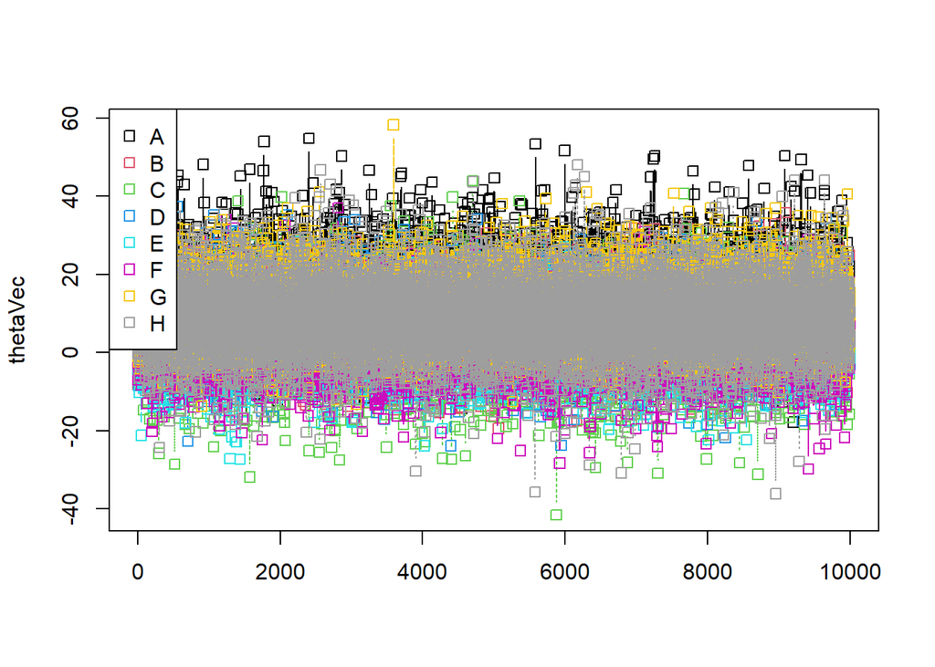

```r
thetaHat = V = thetaVec = matrix(NA, N, J)
for (j in 1:J){
  V[,j] = 1/ (sigma2[j]^-1 + tauVector^-2)
  thetaHat[,j] = (y[j]/sigma2[j] + muVec/tauVector^2) * V[,j]
  thetaVec[, j] = rnorm(N, thetaHat[,j], V[,j]^(1/2))
}


matplot(thetaVec, type = c("b"), pch=0.5, col = 1:ncol(thetaVec)) #plot
legend("topleft", legend = LETTERS[1:8], col=1:ncol(thetaVec), pch=0.5) # optional legend

library(ggplot2)
```

```r
library(tidyr)
```

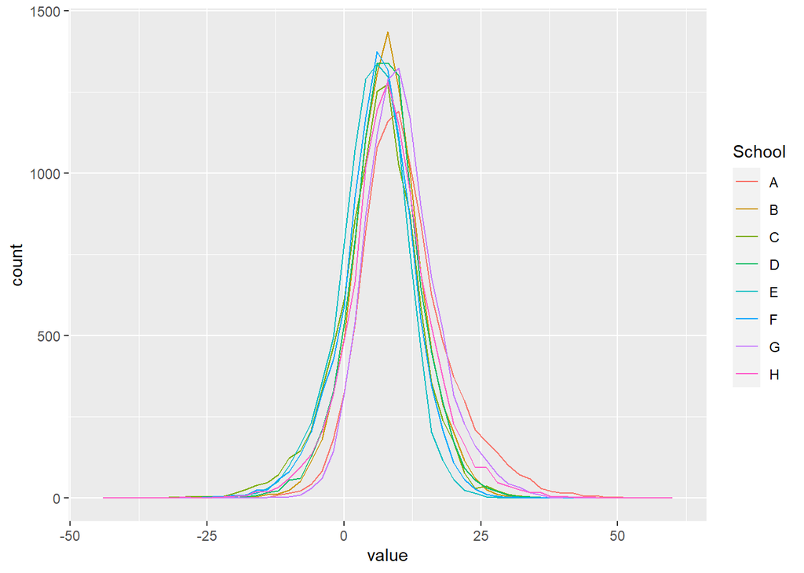

```r
ggplot(gather(data.frame(thetaVec)), aes(value, color=key)) + geom_freqpoly(binwidth=2) +
  scale_color_discrete(name = "School", labels = c("A", "B", "C", "D", "E", "F", "G", "H"))
```

Last we compute the probability of a school $j$ that is better than another school $k$.

```r
maxes = apply(thetaVec, 1, which.max)
prob_max = table(maxes) / N
comps = matrix(NA, J, J)

for (i in 1:(J-1)){
  for (j in (i+1):J){
    comps[i,j] = sum(thetaVec[,i] > thetaVec[,j]) / N
    comps[j,i] = 1 - comps[i,j]
  }
}

pmax = sprintf("%0.2f", prob_max)
comp_str = matrix(sprintf("%0.2f", comps), J, J)
comp_str[comp_str == "NA"] = "--"

schools = c("A", "B", "C", "D", "E", "F", "G", "H")
library(kableExtra)
kable(cbind(schools, pmax, comp_str),
      format = "html", digits = 2,
      col.names = c("School", "Pr(Best)", schools)) %>%
  kable_styling(bootstrap_options = c("striped", "hover"))
```

| School | Pr(Best) | A | B | C | D | E | F | G | H |
| --- | --- | --- | --- | --- | --- | --- | --- | --- | --- |
| A | 0.25 | – | 0.62 | 0.68 | 0.65 | 0.73 | 0.69 | 0.52 | 0.61 |
| B | 0.10 | 0.38 | – | 0.57 | 0.51 | 0.63 | 0.58 | 0.38 | 0.48 |
| C | 0.08 | 0.32 | 0.43 | – | 0.44 | 0.54 | 0.50 | 0.33 | 0.42 |
| D | 0.10 | 0.35 | 0.49 | 0.56 | – | 0.61 | 0.56 | 0.37 | 0.47 |
| E | 0.05 | 0.27 | 0.37 | 0.46 | 0.39 | – | 0.45 | 0.28 | 0.37 |
| F | 0.07 | 0.31 | 0.42 | 0.50 | 0.44 | 0.55 | – | 0.32 | 0.41 |
| G | 0.20 | 0.48 | 0.62 | 0.67 | 0.63 | 0.72 | 0.68 | – | 0.59 |
| H | 0.14 | 0.39 | 0.52 | 0.58 | 0.53 | 0.63 | 0.59 | 0.41 | – |

### Repeat the above using a large $\tau$.

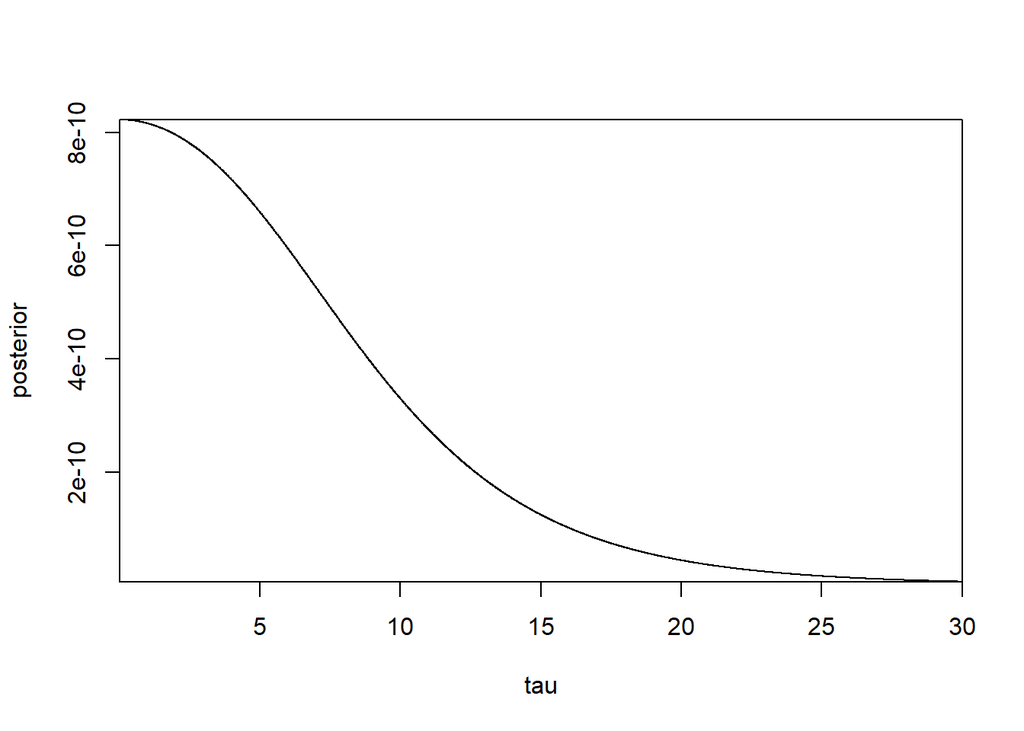

```r
y = c(28, 8, -3, 7, -1, 1, 18, 12)
sigma2 = c(15, 10, 16, 11, 9, 11, 10, 18)^2
J = length(y)

varInverse = function(sigma2, tau){
  sum(1/(sigma2+tau^2))
}

muHat = function(y, sigma2, tau){
  sum(1/(sigma2+tau^2) * y) / varInverse(sigma2, tau)
}

post_tau = function(y, sigma2, tau, mu_h){
  varInverse(sigma2, tau)^(-1/2)  * prod((sigma2 + tau^2)^(-1/2) * exp(-(y - mu_h)^2 / (2*(sigma2 + tau^2))))
}

interval = 0.01
max = 30

tau = (1:(max/interval)) * interval

post = tau

for (i in 1:length(tau)){
  mu_h = muHat(y, sigma2, tau[i])
  post[i] = post_tau(y, sigma2, tau[i], mu_h)
}

posterior = data.frame(tau, post)
plot(posterior, xaxs = "i", yaxs = "i",
     type = "l", ylab = "posterior", xlab = "tau")
```

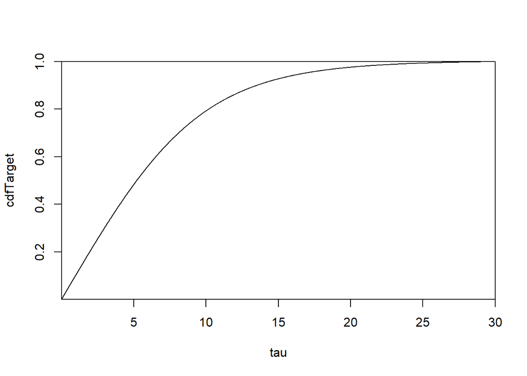

```r
normPosterior = post/sum(post*interval)
cdfTarget = cumsum(normPosterior) * interval
cdfDF = data.frame(tau, cdfTarget)
plot(cdfDF, xaxs = "i", yaxs = "i", type = "l")
```

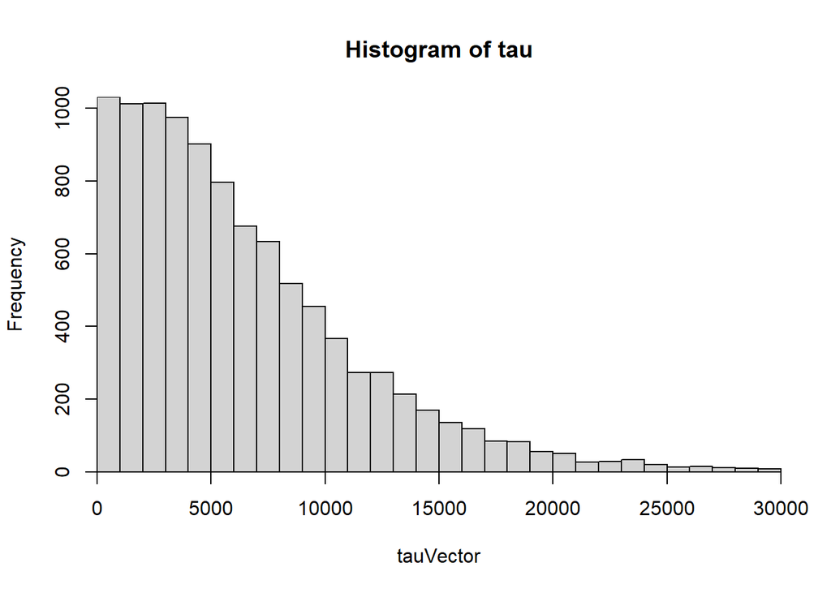

```r
N = 10000
uniDF = runif(N, 0, 1)
tauVector = rep(NA, N)
for (i in 1:N) {
  tauVector[i] = (sum(cdfTarget < uniDF[i])+1) * interval * 1000
}

hist(tauVector, breaks = 30, xaxs = "i", yaxs = "i",
     main = "Histogram of tau")
```

```r
muVec = rep(NA, N)
for (i in 1:N) {
  muVec[i] = rnorm(1, muHat(y, sigma2, tauVector[i]), varInverse(sigma2, tauVector[i])^(-.5))
}
```

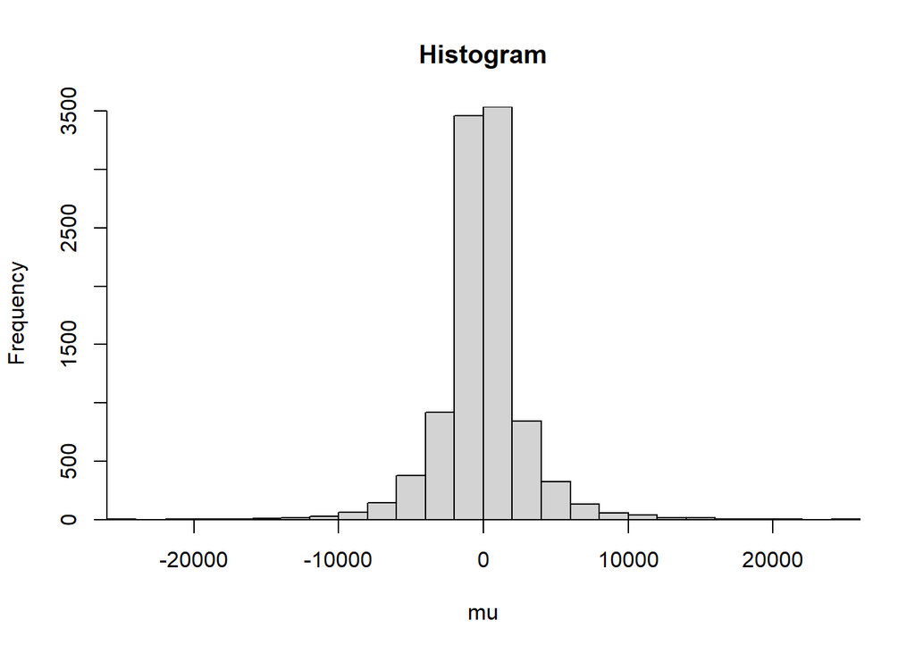

```r
hist(muVec, xaxs = "i", yaxs = "i",
     xlab = "mu",
     main = "Histogram", breaks = 30)
```

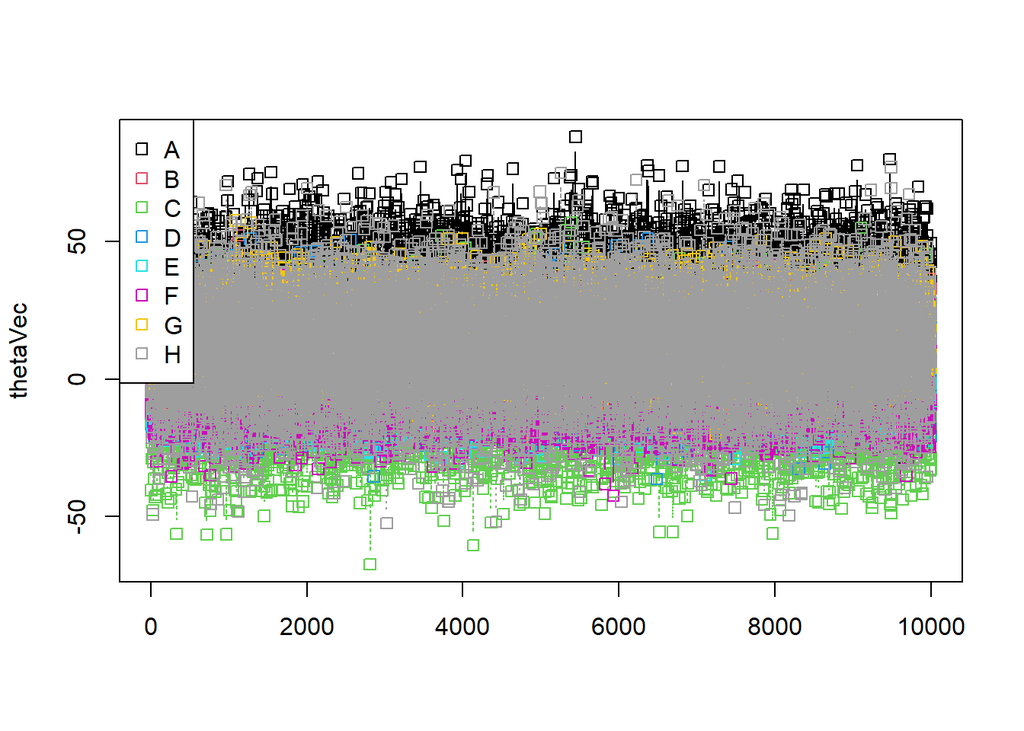

```r
thetaHat = V = thetaVec = matrix(NA, N, J)
for (j in 1:J){
  V[,j] = 1/ (sigma2[j]^-1 + tauVector^-2)
  thetaHat[,j] = (y[j]/sigma2[j] + muVec/tauVector^2) * V[,j]
  thetaVec[, j] = rnorm(N, thetaHat[,j], V[,j]^(1/2))
}

matplot(thetaVec, type = c("b"), pch=0.5, col = 1:ncol(thetaVec)) #plot
legend("topleft", legend = LETTERS[1:8], col=1:ncol(thetaVec), pch=0.5) # optional legend
```

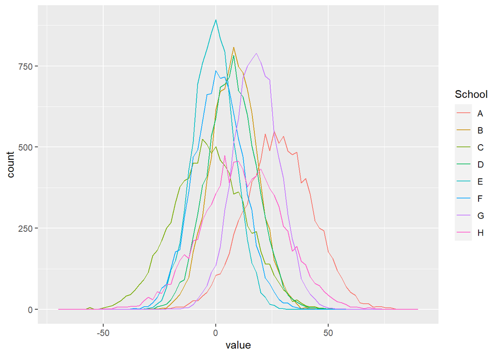

```r
library(ggplot2)
library(tidyr)
ggplot(gather(data.frame(thetaVec)), aes(value, color=key)) + geom_freqpoly(binwidth=2) +
  scale_color_discrete(name = "School", labels = c("A", "B", "C", "D", "E", "F", "G", "H"))
```

```r
maxes = apply(thetaVec, 1, which.max)
prob_max = table(maxes) / N
comps = matrix(NA, J, J)

for (i in 1:(J-1)){
  for (j in (i+1):J){
    comps[i,j] = sum(thetaVec[,i] > thetaVec[,j]) / N
    comps[j,i] = 1 - comps[i,j]
  }
}

pmax = sprintf("%0.2f", prob_max)
comp_str = matrix(sprintf("%0.2f", comps), J, J)
comp_str[comp_str == "NA"] = "--"

schools = c("A", "B", "C", "D", "E", "F", "G", "H")
library(kableExtra)
kable(cbind(schools, pmax, comp_str),
      format = "html", digits = 2,
      col.names = c("School", "Pr(Best)", schools)) %>%
  kable_styling(bootstrap_options = c("striped", "hover"))
```

| School | Pr(Best) | A | B | C | D | E | F | G | H |
| --- | --- | --- | --- | --- | --- | --- | --- | --- | --- |
| A | 0.55 | – | 0.86 | 0.92 | 0.87 | 0.95 | 0.93 | 0.71 | 0.75 |
| B | 0.04 | 0.14 | – | 0.71 | 0.53 | 0.75 | 0.68 | 0.24 | 0.43 |
| C | 0.03 | 0.08 | 0.28 | – | 0.31 | 0.45 | 0.42 | 0.13 | 0.27 |
| D | 0.04 | 0.13 | 0.47 | 0.69 | – | 0.72 | 0.65 | 0.23 | 0.41 |
| E | 0.00 | 0.05 | 0.25 | 0.55 | 0.28 | – | 0.44 | 0.08 | 0.26 |
| F | 0.01 | 0.07 | 0.32 | 0.58 | 0.35 | 0.56 | – | 0.12 | 0.31 |
| G | 0.17 | 0.29 | 0.76 | 0.87 | 0.77 | 0.92 | 0.88 | – | 0.62 |
| H | 0.17 | 0.25 | 0.57 | 0.73 | 0.59 | 0.74 | 0.69 | 0.38 | – |

### Comment

The setting with large $\tau$ gives us more extreme situations. For example, the first row for school A, we have chance that school A is better than the rest of the school (B to H) to be ranging from

```r
print(paste0("Range = [", min(comps[1,-1]), ", ", max(comps[1,-1]), "]"))
```

```
## [1] "Range = [0.707, 0.9509]"
```

Another interesting thing is from the *ggplot* above we see a much wider variance in (b) than in (a) due to this change of setting.

### Change $\tau$ to 0

Let us change $\tau$ to a very small number to approximate 0.

```r
N = 10000
uniDF = runif(N, 0, 1)
tauVector = rep(NA, N)
for (i in 1:N) {
  tauVector[i] = (sum(cdfTarget < uniDF[i])+1) * interval * 0.0001
}

# hist(tauVector, breaks = 30, xaxs = "i", yaxs = "i",
#      main = "Histogram of tau")

muVec = rep(NA, N)
for (i in 1:N) {
  muVec[i] = rnorm(1, muHat(y, sigma2, tauVector[i]), varInverse(sigma2, tauVector[i])^(-.5))
}

# hist(muVec, xaxs = "i", yaxs = "i",
#      xlab = "mu",
#      main = "Histogram", breaks = 30)


thetaHat = V = thetaVec = matrix(NA, N, J)
for (j in 1:J){
  V[,j] = 1/ (sigma2[j]^-1 + tauVector^-2)
  thetaHat[,j] = (y[j]/sigma2[j] + muVec/tauVector^2) * V[,j]
  thetaVec[, j] = rnorm(N, thetaHat[,j], V[,j]^(1/2))
}

# matplot(thetaVec, type = c("b"), pch=0.5, col = 1:ncol(thetaVec)) #plot
# legend("topleft", legend = LETTERS[1:8], col=1:ncol(thetaVec), pch=0.5) # optional legend

# library(ggplot2)
# library(tidyr)
# ggplot(gather(data.frame(thetaVec)), aes(value, color=key)) + geom_freqpoly(binwidth=2) +
#   scale_color_discrete(name = "School", labels = c("A", "B", "C", "D", "E", "F", "G", "H"))

maxes = apply(thetaVec, 1, which.max)
prob_max = table(maxes) / N
comps = matrix(NA, J, J)

for (i in 1:(J-1)){
  for (j in (i+1):J){
    comps[i,j] = sum(thetaVec[,i] > thetaVec[,j]) / N
    comps[j,i] = 1 - comps[i,j]
  }
}

pmax = sprintf("%0.2f", prob_max)
comp_str = matrix(sprintf("%0.2f", comps), J, J)
comp_str[comp_str == "NA"] = "--"

schools = c("A", "B", "C", "D", "E", "F", "G", "H")
library(kableExtra)
kable(cbind(schools, pmax, comp_str),
      format = "html", digits = 2,
      col.names = c("School", "Pr(Best)", schools)) %>%
  kable_styling(bootstrap_options = c("striped", "hover"))
```

| School | Pr(Best) | A | B | C | D | E | F | G | H |
| --- | --- | --- | --- | --- | --- | --- | --- | --- | --- |
| A | 0.12 | – | 0.50 | 0.50 | 0.50 | 0.50 | 0.50 | 0.50 | 0.50 |
| B | 0.12 | 0.50 | – | 0.50 | 0.50 | 0.50 | 0.50 | 0.50 | 0.50 |
| C | 0.13 | 0.50 | 0.50 | – | 0.49 | 0.50 | 0.50 | 0.49 | 0.50 |
| D | 0.12 | 0.50 | 0.50 | 0.51 | – | 0.50 | 0.50 | 0.50 | 0.50 |
| E | 0.13 | 0.50 | 0.50 | 0.50 | 0.50 | – | 0.50 | 0.50 | 0.50 |
| F | 0.13 | 0.50 | 0.50 | 0.50 | 0.50 | 0.50 | – | 0.50 | 0.50 |
| G | 0.12 | 0.50 | 0.50 | 0.51 | 0.50 | 0.50 | 0.50 | – | 0.50 |
| H | 0.13 | 0.50 | 0.50 | 0.50 | 0.50 | 0.50 | 0.50 | 0.50 | – |

From the results of above table, we observe that almost everyone is equal probability. For example, everyone is around 12% chance of being the best (from the first column). This is approximately 1/8.

Another interesting fact is for the first row we observe that the chance for school A to be better than B, C, …, H are equal when they are in a pair-wise comparison. Hence, they are all 50%.